# Uncertainty Propagation in MBBE — Partial Replicate Design

# 12 Run All Methods

```julia
fixed_param_samples = fill(θ̂, 100)

res_fixed = virtual_be_sim(fixed_param_samples, "Fixed")
res_vcov  = virtual_be_sim(vcov_param_samples,  "VCOV")
res_boot  = virtual_be_sim(boot_param_samples,  "Bootstrap")
res_sir   = virtual_be_sim(sir_param_samples,   "SIR")
nothing
```

# 13 Within-Reference %CV for Olanzapine (Partial Replicate)

Within-reference (intra-subject) variability estimated from the paired Reference periods across 100 simulated partial replicate trials (60 subjects, T/R = 1.0). This CV_WR determines whether RSABE (scaled limits) or standard TOST is applied.

```julia
cv_estimates = estimate_cv_within_ref(fixed_param_samples; n_subjects = 60, n_reps = 100)
nothing
```

```
AUC  within-reference %CV_WR = 53.4%
Cmax within-reference %CV_WR = 45.8%

CV_WR > 30% detected → RSABE (scaled limits) applies for the high-variability metric(s).
```

# 14 Combined Summary Results

```julia
all_summary  = vcat(res_fixed.summary, res_vcov.summary, res_boot.summary, res_sir.summary)
all_detailed = vcat(res_fixed.detailed, res_vcov.detailed, res_boot.detailed, res_sir.detailed)
nothing
```

## 14.1 RSABE Pass Rate (Primary)

BE pass rate (%) using RSABE (scaled limits when CV_WR > 30%, unscaled otherwise):

```
### RSABE Pass Rate (%) — 24 Subjects (Partial Replicate)


### RSABE Pass Rate (%) — 30 Subjects (Partial Replicate)


### RSABE Pass Rate (%) — 60 Subjects (Partial Replicate)
```

Table 1

5×5 DataFrame

| Row | tr_ratio Float64 | Fixed Float64? | VCOV Float64? | Bootstrap Float64? | SIR Float64? |
| --- | --- | --- | --- | --- | --- |
| 1 | 0.7 | 0.0 | 4.02685 | 6.0241 | 5.38922 |
| 2 | 0.9 | 0.0 | 6.91824 | 5.45455 | 6.09756 |
| 3 | 1.0 | 0.0 | 4.63576 | 5.38922 | 5.84416 |
| 4 | 1.1 | 0.0 | 4.67836 | 8.69565 | 10.119 |
| 5 | 1.3 | 0.0 | 4.26829 | 3.50877 | 8.69565 |

5×5 DataFrame

| Row | tr_ratio Float64 | Fixed Float64? | VCOV Float64? | Bootstrap Float64? | SIR Float64? |
| --- | --- | --- | --- | --- | --- |
| 1 | 0.7 | 0.0 | 6.11111 | 8.57143 | 7.55814 |
| 2 | 0.9 | 0.0 | 4.65116 | 5.91398 | 6.17978 |
| 3 | 1.0 | 2.0 | 4.94505 | 6.43275 | 5.02793 |
| 4 | 1.1 | 0.502513 | 9.23913 | 8.92857 | 8.48485 |
| 5 | 1.3 | 0.0 | 6.28571 | 5.11364 | 7.18232 |

5×5 DataFrame

| Row | tr_ratio Float64 | Fixed Float64? | VCOV Float64? | Bootstrap Float64? | SIR Float64? |
| --- | --- | --- | --- | --- | --- |
| 1 | 0.7 | 0.5 | 18.8776 | 22.449 | 21.608 |
| 2 | 0.9 | 84.0 | 60.6061 | 64.1414 | 54.7739 |
| 3 | 1.0 | 89.5 | 58.5859 | 58.2915 | 61.1111 |
| 4 | 1.1 | 84.5 | 61.6162 | 63.5 | 60.101 |
| 5 | 1.3 | 31.0 | 19.898 | 22.6131 | 22.449 |

## 14.2 Unscaled TOST Pass Rate (Comparison)

Standard TOST pass rate (%) with fixed 80–125% limits (ignoring RSABE scaling):

```
### Unscaled TOST Pass Rate (%) — 24 Subjects (Partial Replicate)


### Unscaled TOST Pass Rate (%) — 30 Subjects (Partial Replicate)


### Unscaled TOST Pass Rate (%) — 60 Subjects (Partial Replicate)
```

Table 2

5×5 DataFrame

| Row | tr_ratio Float64 | Fixed Float64? | VCOV Float64? | Bootstrap Float64? | SIR Float64? |
| --- | --- | --- | --- | --- | --- |
| 1 | 0.7 | 0.0 | 2.68456 | 3.01205 | 2.39521 |
| 2 | 0.9 | 0.0 | 3.77358 | 4.24242 | 3.65854 |
| 3 | 1.0 | 0.0 | 3.97351 | 4.19162 | 4.54545 |
| 4 | 1.1 | 0.0 | 3.50877 | 4.34783 | 5.35714 |
| 5 | 1.3 | 0.0 | 2.43902 | 1.16959 | 3.72671 |

5×5 DataFrame

| Row | tr_ratio Float64 | Fixed Float64? | VCOV Float64? | Bootstrap Float64? | SIR Float64? |
| --- | --- | --- | --- | --- | --- |
| 1 | 0.7 | 0.0 | 4.44444 | 5.14286 | 5.81395 |
| 2 | 0.9 | 0.0 | 4.06977 | 3.22581 | 3.93258 |
| 3 | 1.0 | 1.0 | 1.64835 | 3.50877 | 3.91061 |
| 4 | 1.1 | 0.0 | 6.52174 | 4.7619 | 6.06061 |
| 5 | 1.3 | 0.0 | 3.42857 | 3.40909 | 5.52486 |

5×5 DataFrame

| Row | tr_ratio Float64 | Fixed Float64? | VCOV Float64? | Bootstrap Float64? | SIR Float64? |
| --- | --- | --- | --- | --- | --- |
| 1 | 0.7 | 0.0 | 12.7551 | 11.7347 | 13.0653 |
| 2 | 0.9 | 0.5 | 14.6465 | 11.6162 | 12.5628 |
| 3 | 1.0 | 5.5 | 11.6162 | 9.04523 | 13.1313 |
| 4 | 1.1 | 3.0 | 10.6061 | 14.0 | 15.1515 |
| 5 | 1.3 | 0.0 | 10.2041 | 7.53769 | 13.7755 |

# 15 Power & Type I Error by Sample Size

### 15.0.1 Mean Power (%) by Sample Size — RSABE, T/R in {0.9, 1.0, 1.1}

Rows = subjects per trial (3 periods each), columns = uncertainty method.

7×5 DataFrame

| Row | n_subjects Int64 | Fixed Float64? | VCOV Float64? | Bootstrap Float64? | SIR Float64? |
| --- | --- | --- | --- | --- | --- |
| 1 | 12 | 0.0 | 4.12645 | 4.20557 | 6.20399 |
| 2 | 24 | 0.0 | 5.41079 | 6.51314 | 7.35359 |
| 3 | 30 | 0.834171 | 6.27845 | 7.09177 | 6.56419 |
| 4 | 40 | 74.8333 | 49.2421 | 48.1955 | 49.3336 |
| 5 | 50 | 84.0 | 51.6554 | 52.6253 | 51.8638 |
| 6 | 60 | 86.0 | 60.2694 | 61.9776 | 58.662 |
| 7 | 80 | 91.3333 | 68.2789 | 66.1156 | 67.1695 |

### 15.0.2 Mean Power (%) by Sample Size — Unscaled TOST, T/R in {0.9, 1.0, 1.1}

7×5 DataFrame

| Row | n_subjects Int64 | Fixed Float64? | VCOV Float64? | Bootstrap Float64? | SIR Float64? |
| --- | --- | --- | --- | --- | --- |
| 1 | 12 | 0.0 | 2.5265 | 2.68734 | 3.25273 |
| 2 | 24 | 0.0 | 3.75196 | 4.26062 | 4.52038 |
| 3 | 30 | 0.333333 | 4.07995 | 3.83216 | 4.6346 |
| 4 | 40 | 1.16667 | 8.37869 | 6.16368 | 9.90537 |
| 5 | 50 | 2.33333 | 10.3833 | 9.3375 | 10.7153 |
| 6 | 60 | 3.0 | 12.2896 | 11.5538 | 13.6152 |
| 7 | 80 | 8.16667 | 13.8559 | 19.3693 | 21.7793 |

### 15.0.3 Mean Type I Error (%) by Sample Size — RSABE, T/R in {0.7, 1.3}

Rows = subjects per trial, columns = uncertainty method.

7×5 DataFrame

| Row | n_subjects Int64 | Fixed Float64? | VCOV Float64? | Bootstrap Float64? | SIR Float64? |
| --- | --- | --- | --- | --- | --- |
| 1 | 12 | 0.0 | 2.46914 | 3.8008 | 3.66667 |
| 2 | 24 | 0.0 | 4.14757 | 4.76643 | 7.04244 |
| 3 | 30 | 0.0 | 6.19841 | 6.84253 | 7.37023 |
| 4 | 40 | 11.0 | 14.3619 | 14.2487 | 15.9246 |
| 5 | 50 | 14.5 | 15.2543 | 17.4861 | 18.0412 |
| 6 | 60 | 15.75 | 19.3878 | 22.531 | 22.0285 |
| 7 | 80 | 17.25 | 22.6626 | 21.75 | 26.5 |

### 15.0.4 Mean Type I Error (%) by Sample Size — Unscaled TOST, T/R in {0.7, 1.3}

7×5 DataFrame

| Row | n_subjects Int64 | Fixed Float64? | VCOV Float64? | Bootstrap Float64? | SIR Float64? |
| --- | --- | --- | --- | --- | --- |
| 1 | 12 | 0.0 | 1.85185 | 2.83926 | 3.11111 |
| 2 | 24 | 0.0 | 2.56179 | 2.09082 | 3.06096 |
| 3 | 30 | 0.0 | 3.93651 | 4.27597 | 5.66941 |
| 4 | 40 | 0.0 | 5.4116 | 5.44041 | 6.88432 |
| 5 | 50 | 0.0 | 8.2728 | 8.63033 | 8.50515 |
| 6 | 60 | 0.0 | 11.4796 | 9.63619 | 13.4204 |
| 7 | 80 | 0.0 | 16.1147 | 11.75 | 17.0 |

# 16 Visualization: Pass Rate by T/R Ratio and Sample Size

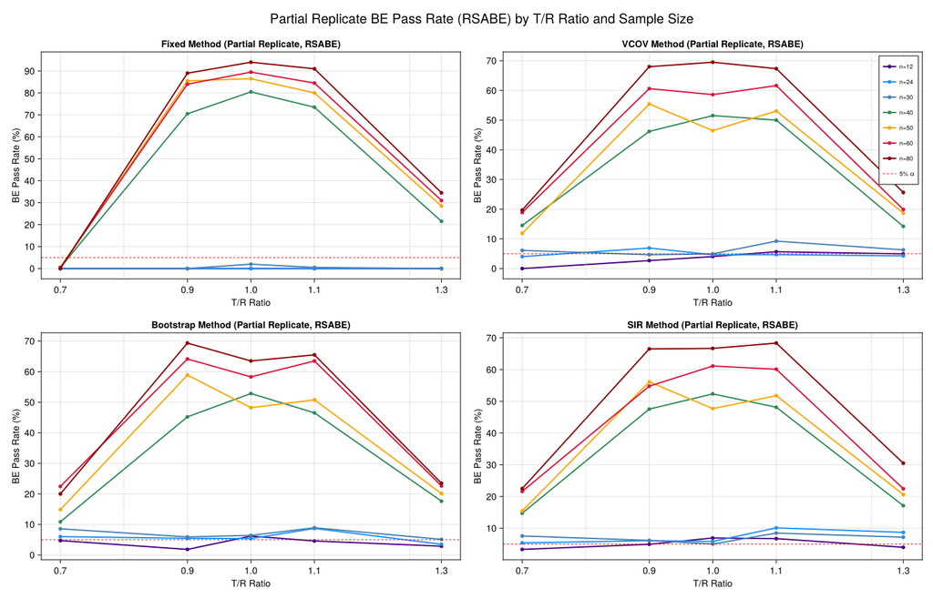

Figure 1: Partial replicate BE pass rate (RSABE) across T/R ratios and sample sizes for each uncertainty method.

```julia
fig1 = Figure(size = (1400, 900))
methods_list = ["Fixed", "VCOV", "Bootstrap", "SIR"]
size_colors  = [:indigo, :dodgerblue, :steelblue, :seagreen, :orange, :crimson, :darkred]

for (idx, m) in enumerate(methods_list)
    row = (idx - 1) ÷ 2 + 1
    col = (idx - 1) % 2 + 1
    ax = Axis(fig1[row, col];
        xlabel = "T/R Ratio",
        ylabel = "BE Pass Rate (%)",
        title  = "$m Method (Partial Replicate, RSABE)",
        xticks = TR_RATIOS,
        yticks = 0:10:100
    )

    sub = filter(r -> r.method == m, all_summary)
    for (j, n) in enumerate(SAMPLE_SIZES)
        sub_n = sort(filter(r -> r.n_subjects == n, sub), :tr_ratio)
        scatterlines!(ax, sub_n.tr_ratio, sub_n.pass_rate;
            label     = "n=$n",
            color     = size_colors[j],
            marker    = :circle,
            markersize = 8,
            linewidth = 2
        )
    end

    hlines!(ax, [5.0]; color = :red, linestyle = :dash, linewidth = 1, label = "5% α")
    vlines!(ax, [0.80, 1.25]; color = :gray70, linestyle = :dot, linewidth = 1)

    if idx == 2
        axislegend(ax; position = :rt, labelsize = 9)
    end
end

supertitle = Label(fig1[0, :], "Partial Replicate BE Pass Rate (RSABE) by T/R Ratio and Sample Size"; fontsize = 20)
fig1
```

# 17 Visualization: Pass Rate Heatmaps

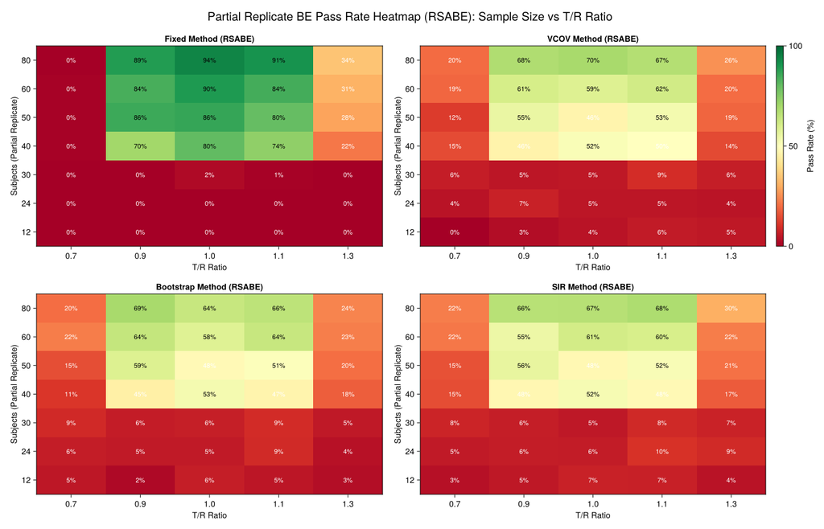

Figure 2: Heatmap of partial replicate BE pass rates (RSABE) by sample size and T/R ratio.

```julia
fig2 = Figure(size = (1400, 900))

for (idx, m) in enumerate(methods_list)
    row = (idx - 1) ÷ 2 + 1
    col = (idx - 1) % 2 + 1

    sub = filter(r -> r.method == m, all_summary)
    mat = zeros(length(SAMPLE_SIZES), length(TR_RATIOS))
    for (i, n) in enumerate(SAMPLE_SIZES), (j, tr) in enumerate(TR_RATIOS)
        r = filter(r -> r.n_subjects == n && r.tr_ratio == tr, sub)
        mat[i, j] = nrow(r) > 0 ? r.pass_rate[1] : NaN
    end

    ax = Axis(fig2[row, col];
        xlabel = "T/R Ratio",
        ylabel = "Subjects (Partial Replicate)",
        title  = "$m Method (RSABE)",
        xticks = (1:length(TR_RATIOS), string.(TR_RATIOS)),
        yticks = (1:length(SAMPLE_SIZES), string.(SAMPLE_SIZES))
    )

    hm = heatmap!(ax, 1:length(TR_RATIOS), 1:length(SAMPLE_SIZES), mat';
        colormap = :RdYlGn, colorrange = (0, 100)
    )

    for (i, n) in enumerate(SAMPLE_SIZES), (j, tr) in enumerate(TR_RATIOS)
        txt = isnan(mat[i, j]) ? "—" : "$(round(Int, mat[i, j]))%"
        text!(ax, j, i; text = txt, align = (:center, :center),
            fontsize = 11, color = mat[i, j] > 50 ? :black : :white)
    end

    if idx == 2
        Colorbar(fig2[row, col + 1], hm; label = "Pass Rate (%)")
    end
end

supertitle2 = Label(fig2[0, :], "Partial Replicate BE Pass Rate Heatmap (RSABE): Sample Size vs T/R Ratio"; fontsize = 20)
fig2
```

# 18 Visualization: Power Curves by Sample Size

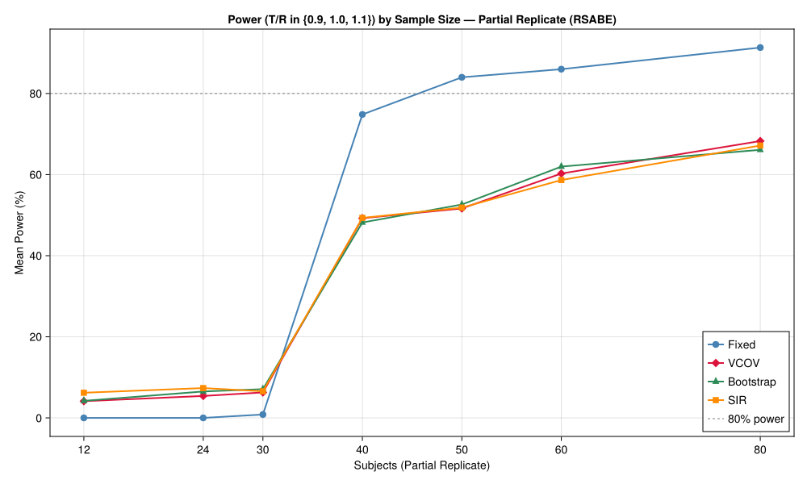

Figure 3: Statistical power by sample size for each uncertainty method (partial replicate, RSABE).

```julia
fig3 = Figure(size = (1000, 600))
ax3 = Axis(fig3[1, 1];
    xlabel = "Subjects (Partial Replicate)",
    ylabel = "Mean Power (%)",
    title  = "Power (T/R in {0.9, 1.0, 1.1}) by Sample Size — Partial Replicate (RSABE)",
    xticks = SAMPLE_SIZES
)

method_colors = [:steelblue, :crimson, :seagreen, :darkorange]
method_shapes = [:circle, :diamond, :utriangle, :rect]

for (i, m) in enumerate(methods_list)
    sub = sort(filter(r -> r.method == m, power_summary), :n_subjects)
    scatterlines!(ax3, sub.n_subjects, sub.mean_power;
        label     = m,
        color     = method_colors[i],
        marker    = method_shapes[i],
        markersize = 12,
        linewidth = 2
    )
end

hlines!(ax3, [80.0]; color = :gray, linestyle = :dash, linewidth = 1, label = "80% power")
axislegend(ax3; position = :rb)
fig3
```

# 19 Visualization: AUC GMR Histograms by T/R Ratio

Using the Fixed method at n = 30 subjects as a representative example.

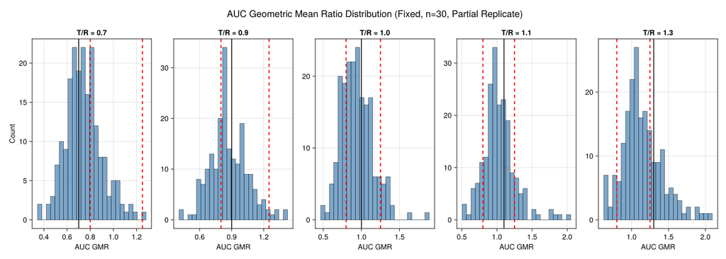

Figure 4: Distribution of AUC geometric mean ratios across simulations (Fixed, n=30, Partial Replicate).

```julia
fig4 = Figure(size = (1400, 500))
detail_sub = filter(r -> r.method == "Fixed" && r.n_subjects == 30, all_detailed)

for (j, tr) in enumerate(TR_RATIOS)
    sub_tr = filter(r -> r.tr_ratio == tr, detail_sub)
    nrow(sub_tr) == 0 && continue

    ax = Axis(fig4[1, j];
        xlabel = "AUC GMR",
        ylabel = j == 1 ? "Count" : "",
        title  = "T/R = $tr"
    )

    hist!(ax, sub_tr.auc_gmr; bins = 25, color = (:steelblue, 0.7), strokecolor = :black, strokewidth = 0.5)
    vlines!(ax, [0.80, 1.25]; color = :red, linestyle = :dash, linewidth = 2)
    vlines!(ax, [tr]; color = :black, linestyle = :solid, linewidth = 1.5)
end

supertitle4 = Label(fig4[0, :], "AUC Geometric Mean Ratio Distribution (Fixed, n=30, Partial Replicate)"; fontsize = 18)
fig4
```

# 20 Visualization: Cmax GMR Histograms by T/R Ratio

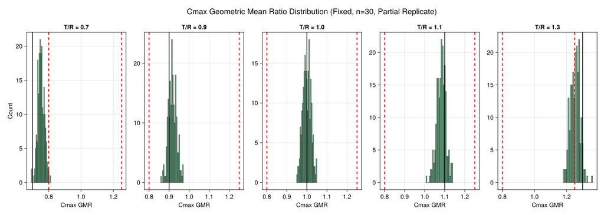

Figure 5: Distribution of Cmax geometric mean ratios across simulations (Fixed, n=30, Partial Replicate).

```julia
fig5 = Figure(size = (1400, 500))

for (j, tr) in enumerate(TR_RATIOS)
    sub_tr = filter(r -> r.tr_ratio == tr, detail_sub)
    nrow(sub_tr) == 0 && continue

    ax = Axis(fig5[1, j];
        xlabel = "Cmax GMR",
        ylabel = j == 1 ? "Count" : "",
        title  = "T/R = $tr"
    )

    hist!(ax, sub_tr.cmax_gmr; bins = 25, color = (:seagreen, 0.7), strokecolor = :black, strokewidth = 0.5)
    vlines!(ax, [0.80, 1.25]; color = :red, linestyle = :dash, linewidth = 2)
    vlines!(ax, [tr]; color = :black, linestyle = :solid, linewidth = 1.5)
end

supertitle5 = Label(fig5[0, :], "Cmax Geometric Mean Ratio Distribution (Fixed, n=30, Partial Replicate)"; fontsize = 18)
fig5
```

# 21 Visualization: 90% CI Bounds (LB and UB) for AUC

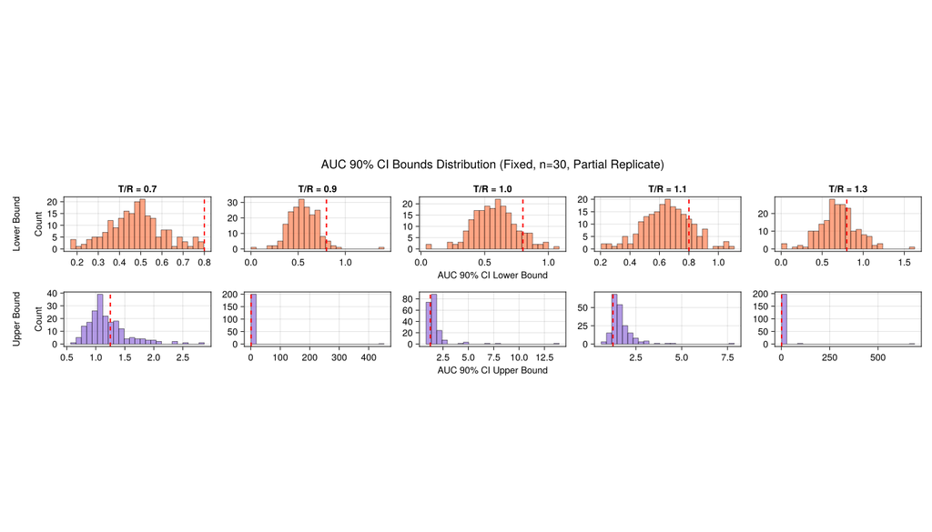

Figure 6: Distribution of AUC 90% CI lower and upper bounds (Fixed, n=30, Partial Replicate).

```julia
fig6 = Figure(size = (1400, 800))

for (j, tr) in enumerate(TR_RATIOS)
    sub_tr = filter(r -> r.tr_ratio == tr, detail_sub)
    nrow(sub_tr) == 0 && continue

    # Lower Bound
    ax_lb = Axis(fig6[1, j];
        xlabel = j == 3 ? "AUC 90% CI Lower Bound" : "",
        ylabel = j == 1 ? "Count" : "",
        title  = "T/R = $tr"
    )
    hist!(ax_lb, sub_tr.auc_lo; bins = 25, color = (:coral, 0.7), strokecolor = :black, strokewidth = 0.5)
    vlines!(ax_lb, [0.80]; color = :red, linestyle = :dash, linewidth = 2, label = "BE limit")

    # Upper Bound
    ax_ub = Axis(fig6[2, j];
        xlabel = j == 3 ? "AUC 90% CI Upper Bound" : "",
        ylabel = j == 1 ? "Count" : ""
    )
    hist!(ax_ub, sub_tr.auc_hi; bins = 25, color = (:mediumpurple, 0.7), strokecolor = :black, strokewidth = 0.5)
    vlines!(ax_ub, [1.25]; color = :red, linestyle = :dash, linewidth = 2, label = "BE limit")
end

Label(fig6[0, :], "AUC 90% CI Bounds Distribution (Fixed, n=30, Partial Replicate)"; fontsize = 18)
Label(fig6[1, 0], "Lower Bound"; fontsize = 14, rotation = pi/2)
Label(fig6[2, 0], "Upper Bound"; fontsize = 14, rotation = pi/2)
fig6
```

# 22 Visualization: Effect of Sample Size on CI Width

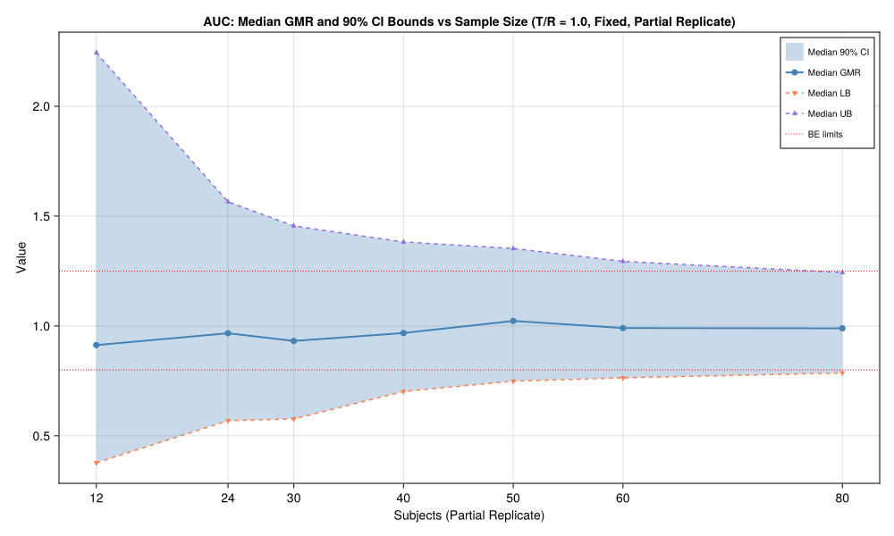

Figure 7: Median AUC GMR and 90% CI bounds narrowing with increasing sample size (Partial Replicate).

```julia
fig7 = Figure(size = (1000, 600))

# Calculate median CI width (AUC) by sample size at T/R = 1.0
detail_tr1 = filter(r -> r.method == "Fixed" && r.tr_ratio == 1.0, all_detailed)

ci_width_summary = combine(
    groupby(detail_tr1, :n_subjects),
    :auc_lo  => median => :median_lb,
    :auc_hi  => median => :median_ub,
    :auc_gmr => median => :median_gmr,
    [:auc_hi, :auc_lo] => ((hi, lo) -> median(hi .- lo)) => :median_ci_width
)
sort!(ci_width_summary, :n_subjects)

ax7 = Axis(fig7[1, 1];
    xlabel = "Subjects (Partial Replicate)",
    ylabel = "Value",
    title  = "AUC: Median GMR and 90% CI Bounds vs Sample Size (T/R = 1.0, Fixed, Partial Replicate)",
    xticks = SAMPLE_SIZES
)

band!(ax7, ci_width_summary.n_subjects,
    ci_width_summary.median_lb, ci_width_summary.median_ub;
    color = (:steelblue, 0.3), label = "Median 90% CI")
scatterlines!(ax7, ci_width_summary.n_subjects, ci_width_summary.median_gmr;
    color = :steelblue, marker = :circle, markersize = 10, linewidth = 2, label = "Median GMR")
scatterlines!(ax7, ci_width_summary.n_subjects, ci_width_summary.median_lb;
    color = :coral, marker = :dtriangle, markersize = 8, linewidth = 1.5, linestyle = :dash, label = "Median LB")
scatterlines!(ax7, ci_width_summary.n_subjects, ci_width_summary.median_ub;
    color = :mediumpurple, marker = :utriangle, markersize = 8, linewidth = 1.5, linestyle = :dash, label = "Median UB")
hlines!(ax7, [0.80, 1.25]; color = :red, linestyle = :dot, linewidth = 1, label = "BE limits")

axislegend(ax7; position = :rt, labelsize = 10)
fig7
```

# 23 Visualization: Overall Pass Rate Comparison

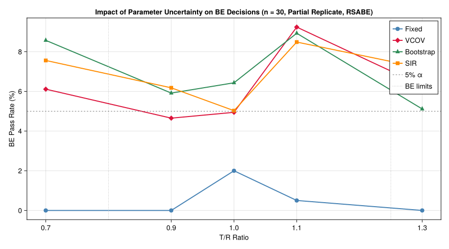

Figure 8: Impact of parameter uncertainty method on partial replicate BE pass rate (n=30 subjects, RSABE).

```julia
fig8 = Figure(size = (900, 500))
ax8 = Axis(fig8[1, 1];
    xlabel = "T/R Ratio",
    ylabel = "BE Pass Rate (%)",
    title  = "Impact of Parameter Uncertainty on BE Decisions (n = 30, Partial Replicate, RSABE)",
    xticks = TR_RATIOS
)

for (i, m) in enumerate(methods_list)
    sub = sort(filter(r -> r.method == m && r.n_subjects == 30, all_summary), :tr_ratio)
    scatterlines!(ax8, sub.tr_ratio, sub.pass_rate;
        label     = m,
        color     = method_colors[i],
        marker    = method_shapes[i],
        markersize = 12,
        linewidth = 2
    )
end

hlines!(ax8, [5.0]; color = :gray, linestyle = :dash, linewidth = 1, label = "5% α")
vlines!(ax8, [0.80, 1.25]; color = :gray70, linestyle = :dot, linewidth = 1, label = "BE limits")

axislegend(ax8; position = :rt)
fig8
```

# 24 Visualization: Type I Error by Sample Size

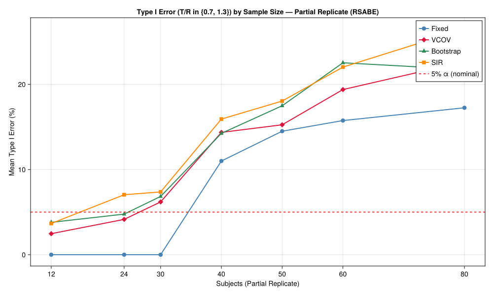

Figure 9: Type I error rate (RSABE) by sample size for each uncertainty method (partial replicate, T/R in {0.7, 1.3}).

```julia
fig_t1e = Figure(size = (1000, 600))
ax_t1e = Axis(fig_t1e[1, 1];
    xlabel = "Subjects (Partial Replicate)",
    ylabel = "Mean Type I Error (%)",
    title  = "Type I Error (T/R in {0.7, 1.3}) by Sample Size — Partial Replicate (RSABE)",
    xticks = SAMPLE_SIZES
)

for (i, m) in enumerate(methods_list)
    sub = sort(filter(r -> r.method == m, t1e_summary), :n_subjects)
    scatterlines!(ax_t1e, sub.n_subjects, sub.mean_type1_error;
        label     = m,
        color     = method_colors[i],
        marker    = method_shapes[i],
        markersize = 12,
        linewidth = 2
    )
end

hlines!(ax_t1e, [5.0]; color = :red, linestyle = :dash, linewidth = 1.5, label = "5% α (nominal)")
axislegend(ax_t1e; position = :rt)
fig_t1e
```

# 25 Visualization: RSABE vs Unscaled TOST Comparison

Comparison of pass rates using RSABE (scaled limits for HVDs) vs standard unscaled TOST (fixed 80–125% limits) at n = 30 subjects, Fixed method.

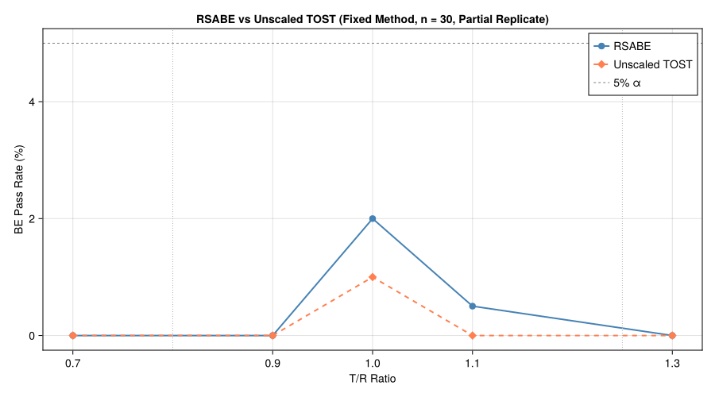

Figure 10: RSABE vs unscaled TOST pass rates at n=30 (Fixed method). RSABE improves power when within-reference CV exceeds 30%.

```julia
fig9 = Figure(size = (900, 500))
ax9 = Axis(fig9[1, 1];
    xlabel = "T/R Ratio",
    ylabel = "BE Pass Rate (%)",
    title  = "RSABE vs Unscaled TOST (Fixed Method, n = 30, Partial Replicate)",
    xticks = TR_RATIOS
)

sub_fixed = sort(filter(r -> r.method == "Fixed" && r.n_subjects == 30, all_summary), :tr_ratio)

scatterlines!(ax9, sub_fixed.tr_ratio, sub_fixed.pass_rate;
    label      = "RSABE",
    color      = :steelblue,
    marker     = :circle,
    markersize = 12,
    linewidth  = 2
)
scatterlines!(ax9, sub_fixed.tr_ratio, sub_fixed.pass_rate_unscaled;
    label      = "Unscaled TOST",
    color      = :coral,
    marker     = :diamond,
    markersize = 12,
    linewidth  = 2,
    linestyle  = :dash
)

hlines!(ax9, [5.0]; color = :gray, linestyle = :dash, linewidth = 1, label = "5% α")
vlines!(ax9, [0.80, 1.25]; color = :gray70, linestyle = :dot, linewidth = 1)

axislegend(ax9; position = :rt)
fig9
```